# Discourse-Oriented German Climate Change Glossary - R Notebook

### Prerequisites

To open and use this notebook file you need to install the following:

```r
#install.packages("quanteda")
#install.packages("readtext")
#install.packages("wordcloud")
#install.packages("RColorBrewer")
#install.packages("wordcloud2")
#install.packages("tidyverse")
#install.packages("tm")
#install.packages("quanteda.textmodels")
#install.packages("quanteda.textstats")
#install.packages("quanteda.textplots")
```

### Load required libraries

```r
# load libraries
library(quanteda)
library(readtext)
library(wordcloud)
library(RColorBrewer)
library(wordcloud2)
library(tidyverse)
library(tm)
library("textcat")
library("quanteda.textplots")
library("quanteda.textstats")
library("gsubfn")
library("spacyr")

spacy_initialize(model = "de_core_news_sm")
```

## 1. Web Scraping with Trafilatura

This step is necessary to get the text data from the websites. In a first step, a list of links of all the subpages of a website is being created. Next, this list of links is processed and the text data is being retrieved and saved in .txt files. This was done in the terminal, not in R.

## 2. Corpus Creation

Hint: All final corpora can be found within the folder “corpora”. You can skip the following steps of the corpus creation and directly start with “3. Corpus Statistics” to run the notebook since the corpus creation takes some time.

To open the previously created text files, we need to run the following code:

```r
# you can get the current directory for importing the text files by setting current directory and open relative path from there with the following line:

#setwd("/Users/Anna/Documents/uni/climate_change_glossary")

# load climate change activists texts
fff_de_texts <- readtext("text_files/pro/fff_de_texts/*")
ikem_texts <- readtext("text_files/pro/ikem_texts/*")
klimarep_texts <- readtext("text_files/pro/klimareporter_texts/*")
klimafakten_texts <- readtext("text_files/pro/klimafakten_texts/*")
zero_texts <- readtext("text_files/pro/germanzero_texts/*")
komma_texts <- readtext("text_files/pro/komma_texts/*")

# load climate change sceptics texts
eike_texts <- readtext("text_files/contra/eike_texts/*")
```

### Building a Corpus

```r
# build corpus for each text with "origin" tag
# specify language for each text to get rid of non-German texts

# activists
fff_de_corpus <- corpus(fff_de_texts)
docvars(fff_de_corpus, "origin") <- "fff_de"
docvars(fff_de_corpus, "language") <- textcat(fff_de_corpus)
fff_de_corpus <- corpus_subset(fff_de_corpus, language == "german", drop_docid = TRUE)

ikem_corpus <- corpus(ikem_texts)
docvars(ikem_corpus, "origin") <- "ikem"
docvars(ikem_corpus, "language") <- textcat(ikem_corpus)
ikem_corpus <- corpus_subset(ikem_corpus, language == "german", drop_docid = TRUE)

klimarep_corpus <- corpus(klimarep_texts)
docvars(klimarep_corpus, "origin") <- "kr"
docvars(klimarep_corpus, "language") <- textcat(klimarep_corpus)
klimarep_corpus <- corpus_subset(klimarep_corpus, language == "german", drop_docid = TRUE)

klimafakten_corpus <- corpus(klimafakten_texts)
docvars(klimafakten_corpus, "origin") <- "kf"
docvars(klimafakten_corpus, "language") <- textcat(klimafakten_corpus)
klimafakten_corpus <- corpus_subset(klimafakten_corpus, language == "german", drop_docid = TRUE)

zero_corpus <- corpus(zero_texts)
docvars(zero_corpus, "origin") <- "zero"
docvars(zero_corpus, "language") <- textcat(zero_corpus)
zero_corpus <- corpus_subset(zero_corpus, language == "german", drop_docid = TRUE)

komma_corpus <- corpus(komma_texts)
docvars(komma_corpus, "origin") <- "gk"
docvars(komma_corpus, "language") <- textcat(komma_corpus)
komma_corpus <- corpus_subset(komma_corpus, language == "german", drop_docid = TRUE)

# sceptics
eike_corpus <- corpus(eike_texts)
docvars(eike_corpus, "origin") <- "eike"
docvars(eike_corpus, "language") <- textcat(eike_corpus)
eike_corpus <- corpus_subset(eike_corpus, language == "german", drop_docid = TRUE)

# build a PRO corpus for all activists texts
# create a "group" tag with value "activists"
pro_corpus <- fff_de_corpus+ikem_corpus+klimarep_corpus+klimafakten_corpus+zero_corpus+komma_corpus
docvars(pro_corpus, "group") <- "activists"

# build a CONTRA corpus for all sceptics texts
# create a "group" tag with value "sceptics"
contra_corpus <- eike_corpus
docvars(contra_corpus, "group") <- "sceptics"
```

### Create Subcorpora (2000 texts each)

```r
# get random sample corpus for activists
pro2000 <- corpus_sample(pro_corpus, size = 2000)

# get random sample corpus for sceptics
contra2000 <- corpus_sample(contra_corpus, size = 2000)

# create "full" (combined) corpus with pro and contra sample
full_corpus <- pro2000+contra2000

# get id number for corpus
docvars(pro2000, "id") <- paste(1:ndoc(pro2000))
docvars(contra2000, "id") <- paste(1:ndoc(contra2000))
```

### Save corpus files in .rds format

```r
# save corpus files as .rds file for later use
saveRDS(full_corpus, "corpora/full_corpus.rds")

saveRDS(pro_corpus, "corpora/pro_corpus.rds")
saveRDS(contra_corpus, "corpora/contra_corpus.rds")

saveRDS(pro2000, "corpora/pro2000.rds")
saveRDS(contra2000, "corpora/contra2000.rds")

# activists
saveRDS(fff_de_corpus, "corpora/fff_de_corpus.rds")
saveRDS(ikem_corpus, "corpora/ikem_corpus.rds")
saveRDS(klimarep_corpus, "corpora/klimarep_corpus.rds")
saveRDS(klimafakten_corpus, "corpora/klimafakten_corpus.rds")
saveRDS(zero_corpus, "corpora/zero_corpus.rds")
saveRDS(komma_corpus, "corpora/komma_corpus.rds")

# sceptics
saveRDS(eike_corpus, "corpora/eike_corpus.rds")
```

## 3. Corpus Statistics

### Load existing corpus files

```r
# load corpus files
full_corpus = readRDS("corpora/full_corpus.rds")

pro_corpus = readRDS("corpora/pro_corpus.rds")
contra_corpus = readRDS("corpora/contra_corpus.rds")

pro2000 = readRDS("corpora/pro2000.rds")
contra2000 = readRDS("corpora/contra2000.rds")

# optional: load
fff_de_corpus = readRDS("corpora/fff_de_corpus.rds")
ikem_corpus = readRDS("corpora/ikem_corpus.rds")
klimarep_corpus = readRDS("corpora/klimarep_corpus.rds")
klimafakten_corpus = readRDS("corpora/klimafakten_corpus.rds")
zero_corpus = readRDS("corpora/zero_corpus.rds")
komma_corpus = readRDS("corpora/komma_corpus.rds")
eike_corpus = readRDS("corpora/eike_corpus.rds")
```

### Exploring the corpus

First, we want to have a look at the information each of the sample corpora gives us:  
- types  
- tokens  
- number of sentences  
- origin  
- language  
- group  
- id

```r
# retrieve overview of corpus information for activists corpus
summary(pro2000, n = 10)
```

```
Corpus consisting of 2000 documents, showing 10 documents:

             Text Types Tokens Sentences origin language     group id
   ikem_00467.txt    27     30         2   ikem   german activists  1
   ikem_00746.txt    27     30         2   ikem   german activists  2
 fff_de_00139.txt   605   1348        59 fff_de   german activists  3
 fff_de_00311.txt   482   1015        70 fff_de   german activists  4
   ikem_00449.txt    27     30         2   ikem   german activists  5
   ikem_01109.txt    66     92         4   ikem   german activists  6
   ikem_00573.txt   710   2100       106   ikem   german activists  7
   ikem_00565.txt   196    307        15   ikem   german activists  8
 fff_de_00052.txt   216    344        17 fff_de   german activists  9
   ikem_01414.txt    31     33         2   ikem   german activists 10
```

```r
# retrieve overview of corpus information for sceptics corpus
summary(contra2000, n=10)
```

```
Corpus consisting of 2000 documents, showing 10 documents:

           Text Types Tokens Sentences origin language    group id
 eike_00744.txt   678   1388        48   eike   german sceptics  1
 eike_03192.txt    22     28         2   eike   german sceptics  2
 eike_06606.txt   720   1626        79   eike   german sceptics  3
 eike_00911.txt   595   1269        62   eike   german sceptics  4
 eike_01046.txt  5216  27652      1294   eike   german sceptics  5
 eike_12137.txt    23     29         2   eike   german sceptics  6
 eike_12127.txt    21     26         2   eike   german sceptics  7
 eike_10148.txt    41     47         2   eike   german sceptics  8
 eike_02519.txt  1243   2922       157   eike   german sceptics  9
 eike_12067.txt   412    763        33   eike   german sceptics 10
```

### Plotting Number of Sentences

The overview of the corpus information reveals that the sceptics corpus may consist of much longer texts (see “Sentences” counts) than the activists corpus. We want to re-check this information by plotting the sentence counts for a subset of the data.

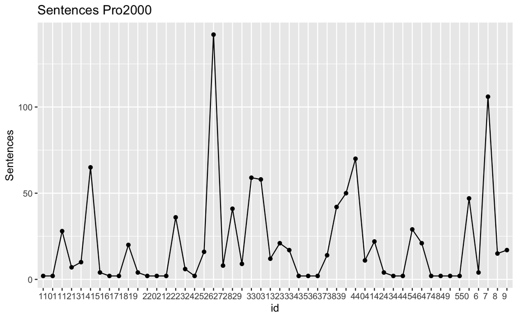

```r
# retrieve corpus information (sample of 50 entries)
contra2000_sum <- summary(contra2000, n=50)
pro2000_sum <- summary(pro2000, n=50)

# create plots from corpus information
ggplot(pro2000_sum, aes(id, Sentences, group=1)) +
  geom_line() +
  geom_point() +
  theme(axis.text.x = element_text(angle=0, vjust=1, hjust=1)) +
  ggtitle("Sentences Pro2000")
```

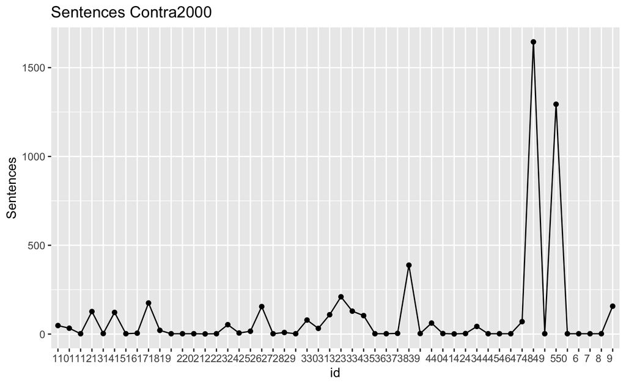

```r
ggplot(contra2000_sum, aes(id, Sentences, group=1)) +
  geom_line() +
  geom_point() +
  theme(axis.text.x = element_text(angle=0, vjust=1, hjust=1)) +
  ggtitle("Sentences Contra2000")
```

Now we can caluculate the mean count of the sentences by running the following code:

```r
# get mean of sentences count for activitst
sents_pro = summary(pro2000, n=ndoc(pro2000))$Sentences
mean(sents_pro)
```

```
[1] 24.704
```

```r
# get mean of sentences count for sceptics
sents_con = summary(contra2000, n=ndoc(contra2000))$Sentences
mean(sents_con)
```

```
[1] 76.3365
```

The results show, that the texts of the activists corpus consist of averagely 24,7 sentences, meanwhile the texts of the sceptics corpus have an average number of 76,3 sentences. This suggests that the texts of the sceptics corpus are much longer than the ones in the other corpus.

## 4. Empirical Work

### Create a Document-Feature Matrix (dfm), load stop lists

```r
# retrieve stoplists
de_stopwords <- stopwords::stopwords("de", source="snowball")
en_stopwords <- stopwords::stopwords("en", source="snowball" )

# add custom stoplist
custom_stopwords <- c("dass", "=", "the", "seit", "ab", "beim", "\n", "mal", "c", "\\|","|", "m", "kommentare", "neueste", "gepostet", "admin", "cookies", "inhalte", "inhalt", "newsletter", "posten", "zugriff", "passwort", "geschützt", "seite", "website", "webseite", "and", "0", "1", "2", "3","4","5","6","7","8","9", "mfg","w","t","wer","00", "30", ">", "anmelden", "\\+", "40", "81", "erneuerbarer",
"OWLIT", "et", "\\´", "\\^", "tppubtype", "pubstate", "z", "b", "d", "ct")

# combine lists to a full version
full_stopwords <- c(de_stopwords,en_stopwords,custom_stopwords)

# create dfm
dfm_p2000 <- dfm(pro2000, remove=full_stopwords, remove_punct=TRUE, remove_numbers=TRUE, remove_symbols=TRUE, tolower=TRUE)
dfm_c2000 <- dfm(contra2000, remove=full_stopwords, remove_punct=TRUE, remove_numbers=TRUE, remove_symbols=TRUE, tolower=TRUE)
```

Let’s have a look at the dfm of both corpora:

```r
# pro corpus dfm
dfm_p2000
```

```
Document-feature matrix of: 2,000 documents, 60,037 features (99.72% sparse) and 4 docvars.
                  features
docs               bleiben laufenden unsere arbeit aktuelle klimapolitische themen erfahren mehr menschen
  ikem_00467.txt         1         1      1      1        1               1      1        1    2        1
  ikem_00746.txt         1         1      1      1        1               1      1        1    2        1
  fff_de_00139.txt       0         0      5      0        0               0      0        0    6        6
  fff_de_00311.txt       0         0      3      0        0               0      0        0    4        1
  ikem_00449.txt         1         1      1      1        1               1      1        1    2        1
  ikem_01109.txt         0         0      0      0        0               0      0        0    0        0
[ reached max_ndoc ... 1,994 more documents, reached max_nfeat ... 60,027 more features ]
```

```r
# contra corpus dfm
dfm_c2000
```

```
Document-feature matrix of: 2,000 documents, 150,453 features (99.71% sparse) and 4 docvars.
                features
docs             diesjährige märzspitze minimal differenz unterhalb grenze messgenauigkeit sorgfältig
  eike_00744.txt           1          1       1         1         1      1               1          1
  eike_03192.txt           0          0       0         0         0      0               0          0
  eike_06606.txt           0          0       0         0         0      0               0          0
  eike_00911.txt           0          0       0         0         0      0               0          0
  eike_01046.txt           0          0       1         5         1      2               0          1
  eike_12137.txt           0          0       0         0         0      0               0          0
                features
docs             geeichten messstation
  eike_00744.txt         1           1
  eike_03192.txt         0           0
  eike_06606.txt         0           0
  eike_00911.txt         0           0
  eike_01046.txt         0           0
  eike_12137.txt         0           0
[ reached max_ndoc ... 1,994 more documents, reached max_nfeat ... 150,443 more features ]
```

The document-feature matrix basically consists of rows for each text and columns for each word (here called “feature”) in the texts. The column values reflect how many times a term appears in a text - if a term does not occur in a text, its value is zero.

### 4.1 Corpus Cleaning

To clean the corpora lemmatization and application of stop lists (see previous step) was performed. For the lemmatization, the spacyr library was used.

Info: This piece of code takes some time to run.

```r
# parse the pro corpus with spacy function and retrieve lemma for each token
sp_pro2000 <- spacy_parse(pro2000, pos=FALSE, entity=FALSE, dependency=FALSE)
sp_pro2000$token <- sp_pro2000$lemma

# create lemmatized version of dfm for activists corpus
sp_dfm_p2000 <- as.tokens(sp_pro2000)%>%
  dfm(remove=full_stopwords, remove_punct=TRUE, remove_numbers=TRUE, remove_symbols=TRUE, tolower=TRUE)

# parse the contra corpus with spacy function and retrieve lemma for each token
sp_contra2000 <- spacy_parse(contra2000, pos=FALSE, entity=FALSE, dependency=FALSE)
sp_contra2000$token <- sp_contra2000$lemma

# create lemmatized version of dfm for sceptics corpus
sp_dfm_c2000 <- as.tokens(sp_contra2000)%>%
  dfm(remove=full_stopwords, remove_punct=TRUE, remove_numbers=TRUE, remove_symbols=TRUE, tolower=TRUE)

# parse the full corpus with spacy function and retrieve lemma for each token
sp_full <- spacy_parse(full_corpus, pos=FALSE, entity=FALSE, dependency=FALSE)
sp_full$token <- sp_full$lemma

# create lemmatized version of dfm for sceptics corpus
sp_dfm_full <- as.tokens(sp_full) %>%
  dfm(remove=full_stopwords, remove_punct=TRUE, remove_numbers=TRUE, remove_symbols=TRUE, tolower=TRUE)
```

Comment: The German lemmatization with spacyr is not very accurate. A lot of compounds do not get lemmatized at all and therefore appear multiple times (in all possible forms) in the dfm.

### 4.2 Frequency Analysis

#### Most frequent terms

With the help of “topfeatures” we can check the most frequently occurring terms for each dfm.

```r
# check top 50 terms for activists corpus
topfeatures(sp_dfm_p2000, n=50)
```

```
        mehr          uhr         ikem       mensch         jahr         weit  deutschland        geben
        4284         3497         2657         2462         2062         1698         1645         1602
     energie        thema      aktuell       sollen         groß        gehen  klimaschutz          gut
        1593         1401         1362         1323         1318         1300         1289         1276
       sowie        immer      bleiben  information       müssen        schon        dabei       future
        1210         1156         1151         1150         1144         1083         1021          991
      arbeit       stehen energiewende      politik       finden        welch         land      projekt
         976          927          902          895          891          887          876          869
        ziel      wichtig       berlin       kommen      fridays     erfahren          jed      zukunft
         863          852          846          838          830          825          813          811
  klimakrise         ganz          neu       rahmen     laufende      möglich         erst        frage
         796          768          750          748          740          735          721          717
       dafür       fahren
         715          712
```

```r
# check top 50 terms for sceptics corpus
topfeatures(sp_dfm_c2000, n=50)
```

```
       jahr       geben        mehr       schon       immer      kommen         gut        weit       gehen
       9280        6899        6351        4630        4394        4123        4056        4024        3802
     sollen          ja       sagen      mensch     energie         co2 deutschland        groß       welch
       3782        3768        3670        3558        3532        3523        3497        3480        3304
        jed      zeigen        hoch  temperatur       wenig        ganz      müssen      global       sehen
       3232        3029        2959        2937        2902        2811        2598        2557        2502
  natürlich       strom        herr        zeit        erde        erst     einfach       heute      finden
       2394        2300        2299        2275        2243        2231        2203        2188        2177
      klima      stehen       frage        land      liegen        etwa        welt klimawandel   erwärmung
       2165        2164        2080        2019        2018        1986        1948        1889        1888
    bereits      lassen       genau      wissen         tun
       1843        1808        1807        1787        1771
```

Since those lists are not easy to handle, we will create a plot of the information in the following sections.

#### Plotting Frequencies

To plot the most frequent words of each corpus, let’s run the following code:

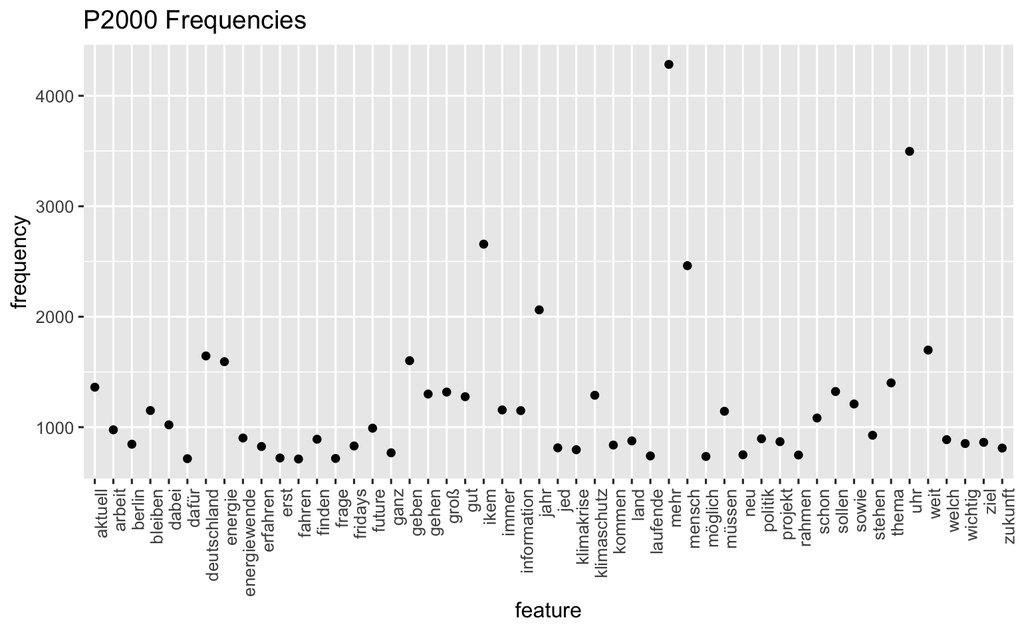

```r
# get frequencies of a sample of 50 words from the corpora
freq_p2000 <- textstat_frequency(sp_dfm_p2000, n=50)
freq_c2000 <- textstat_frequency(sp_dfm_c2000, n=50)

# create plot for activists corpus word frequencies
plot1 <- ggplot(freq_p2000, aes(x=feature, y=frequency)) +
  geom_point()+ggtitle("P2000 Frequencies")+
  theme(axis.text.x = element_text(angle=90,hjust=1))
plot1
```

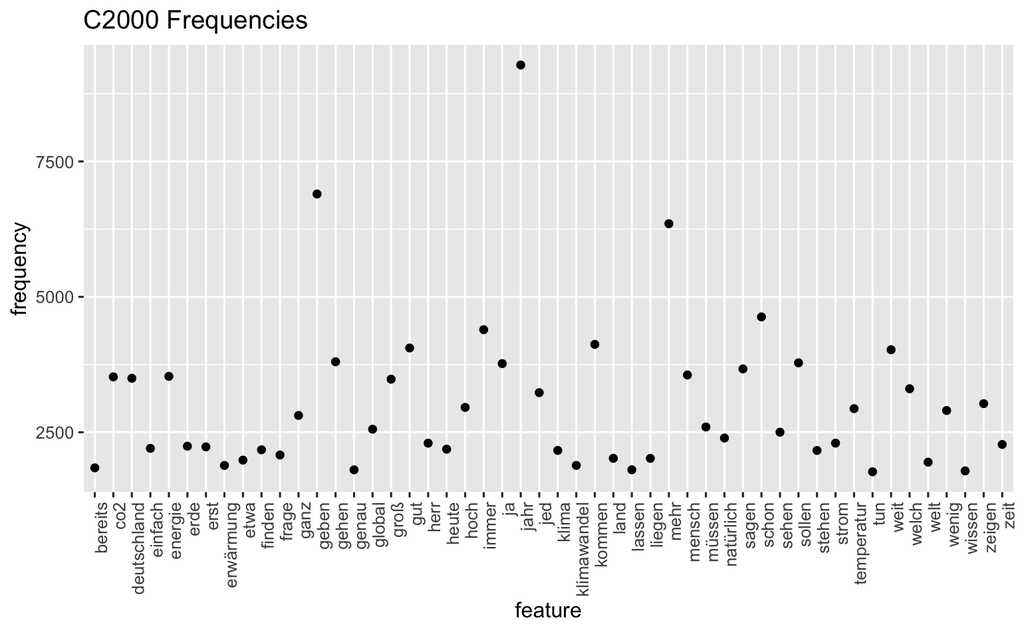

```r
# create plot for sceptics corpus word frequencies
plot2 <- ggplot(freq_c2000, aes(x=feature, y=frequency)) +
  geom_point()+ ggtitle("C2000 Frequencies")+
  theme(axis.text.x = element_text(angle=90,hjust=1))
plot2
```

This already gives us a first impression of the content of the corpora texts.

Nevertheless, we are particularly interested in the word frequencies of German climate change compound nouns. Accordingly, we start with the retrieval of terms starting with “klima” to hopefully get some climate change compounds. In the next step, again we retrieve the frequencies of the words and create plots for both corpora.

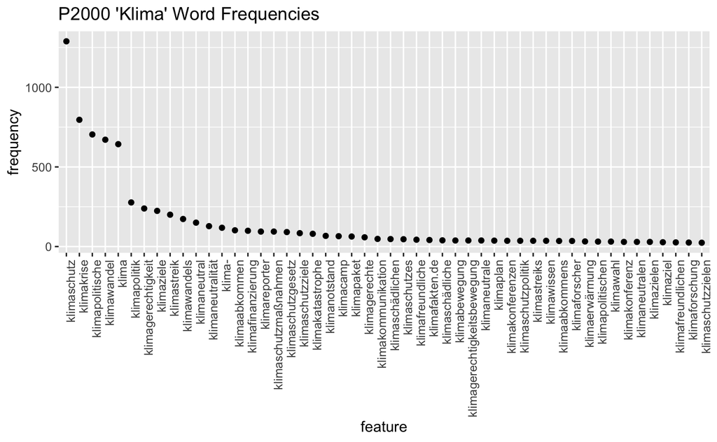

```r
# create a sample of the dfm with all words starting with "klima..."
klima_p2000 <- dfm_select(sp_dfm_p2000, pattern="klima*")
klima_c2000 <- dfm_select(sp_dfm_c2000, pattern="klima*")

# retrieve frequencies for a sample of 50 words
freq_klima_p2000 <- textstat_frequency(klima_p2000, n=50)
freq_klima_c2000 <- textstat_frequency(klima_c2000, n=50)

# sort in descending manner
freq_klima_p2000$feature <- with(freq_klima_p2000, reorder(feature, -frequency))
freq_klima_c2000$feature <- with(freq_klima_c2000, reorder(feature, -frequency))

# create plot for activists corpus "klima" word frequencies
plot3 <- ggplot(freq_klima_p2000, aes(x=feature, y=frequency)) +
  geom_point()+ggtitle("P2000 'Klima' Word Frequencies")+
  theme(axis.text.x = element_text(angle=90,hjust=1))
plot3
```

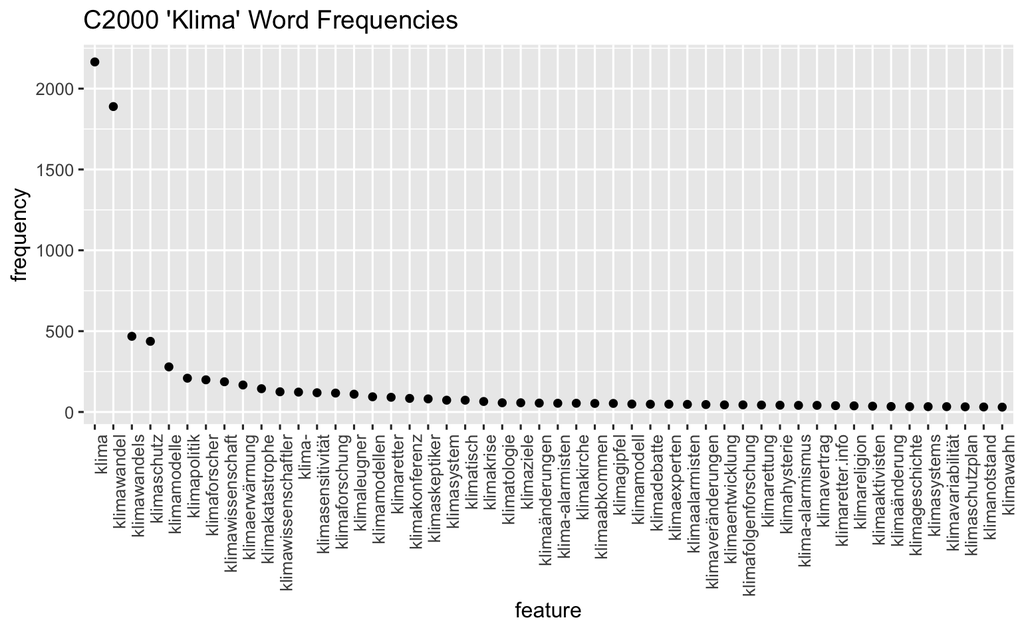

```r
# create plot for scpetics corpus "klima" word frequencies
plot4 <- ggplot(freq_klima_c2000, aes(x=feature, y=frequency)) +
  geom_point()+ ggtitle("C2000 'Klima' Word Frequencies")+
  theme(axis.text.x = element_text(angle=90,hjust=1))
plot4
```

In the following step we retrieve lists of the terms which only appear in one of the Top50 lists. For activists group:

```r
# get list of climate change compounds only appearing in top50 for activists
setdiff(freq_klima_p2000$feature, freq_klima_c2000$feature)
```

```
 [1] "klimapolitische"             "klimagerechtigkeit"          "klimastreik"
 [4] "klimaneutral"                "klimaneutralität"            "klimafinanzierung"
 [7] "klimareporter"               "klimaschutzmaßnahmen"        "klimaschutzgesetz"
[10] "klimaschutzziele"            "klimacamp"                   "klimapaket"
[13] "klimagerechte"               "klimakommunikation"          "klimaschädlichen"
[16] "klimaschutzes"               "klimafreundliche"            "klimafakten.de"
[19] "klimaschädliche"             "klimaneutrale"               "klimagerechtigkeitsbewegung"
[22] "klimabewegung"               "klimaplan"                   "klimastreiks"
[25] "klimawissen"                 "klimakonferenzen"            "klimaschutzpolitik"
[28] "klimaabkommens"              "klimapolitischen"            "klimawahl"
[31] "klimaneutralen"              "klimazielen"                 "klimaziel"
[34] "klimafreundlichen"           "klimaschutzzielen"
```

For sceptics group:

```r
# get list of climate change compounds only appearing in top50 for activists
setdiff(freq_klima_c2000$feature, freq_klima_p2000$feature)
```

```
 [1] "klimamodelle"         "klimawissenschaft"    "klimawissenschaftler" "klimasensitivität"
 [5] "klimaleugner"         "klimamodellen"        "klimaretter"          "klimaskeptiker"
 [9] "klimasystem"          "klimatisch"           "klimatologie"         "klimaänderungen"
[13] "klimakirche"          "klima-alarmisten"     "klimagipfel"          "klimamodell"
[17] "klimadebatte"         "klimaexperten"        "klimaalarmisten"      "klimaveränderungen"
[21] "klimafolgenforschung" "klimaentwicklung"     "klimarettung"         "klimahysterie"
[25] "klima-alarmismus"     "klimavertrag"         "klimaretter.info"     "klimareligion"
[29] "klimaaktivisten"      "klimaänderung"        "klimageschichte"      "klimasystems"
[33] "klimavariabilität"    "klimaschutzplan"      "klimawahn"
```

#### TF-IDF

To get weighted frequencies of the corpora, it is necessary to have a look at the tf-idf (term frequency-inverse document freqeuncy) of the words.

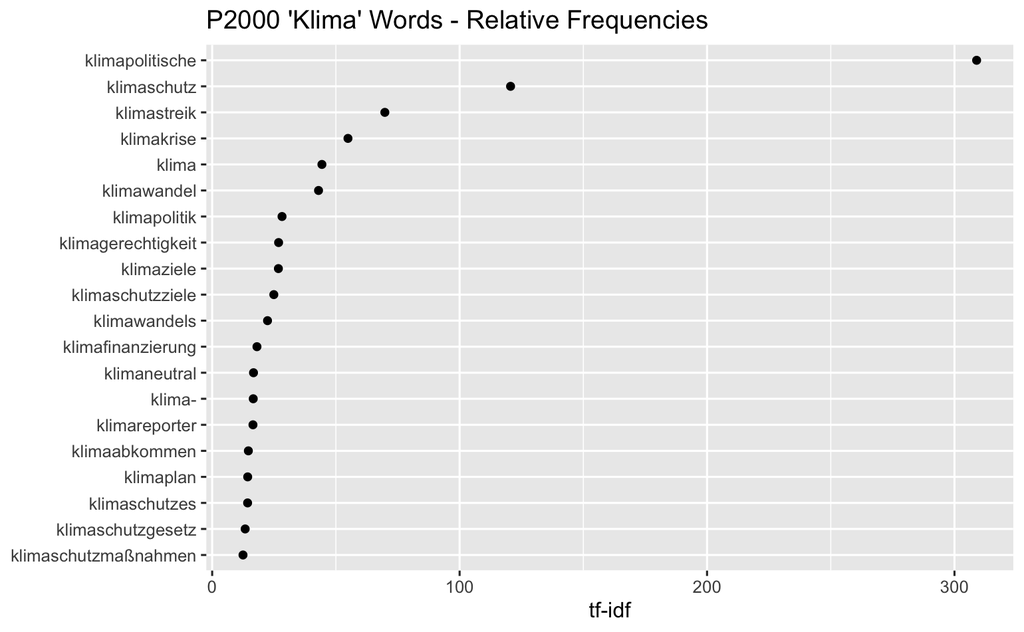

```r
# calculate tfidf for "klima" words
p2000_tfidf <- dfm_tfidf(klima_p2000, scheme_tf = "prop", scheme_df = "inverse")
c2000_tfidf <- dfm_tfidf(klima_c2000, scheme_tf = "prop", scheme_df = "inverse")

# retrieve frequencies
pro_freq_tfidf <- p2000_tfidf %>%
  textstat_frequency(n=20, force=TRUE)

con_freq_tfidf <- c2000_tfidf %>%
  textstat_frequency(n=20, force=TRUE)

# plot tfidf of activists corpus
plot5 <- ggplot(data=pro_freq_tfidf, aes(x=factor(nrow(pro_freq_tfidf):1), y=frequency)) +
  geom_point() +
  ggtitle("P2000 'Klima' Words - Relative Frequencies")+
  coord_flip() +
  scale_x_discrete(breaks=factor(nrow(pro_freq_tfidf):1), labels=pro_freq_tfidf$feature) +
  labs(x=NULL, y="tf-idf")
plot5
```

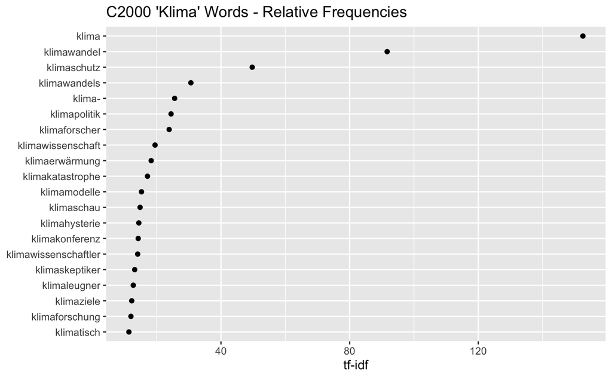

```r
# plot tfidf of sceptics corpus
plot6 <- ggplot(data=con_freq_tfidf,aes(x=factor(nrow(con_freq_tfidf):1), y=frequency)) +
  geom_point() +
  ggtitle("C2000 'Klima' Words - Relative Frequencies")+
  coord_flip() +
  scale_x_discrete(breaks=factor(nrow(con_freq_tfidf):1), labels=con_freq_tfidf$feature) +
  labs(x=NULL, y="tf-idf")
plot6
```

#### Comparison of Groups/Origin

Additionally, let’s have a look at the climate change terms for each website we created our corpora from. All except from EIKE are used to construct the activists corpus.

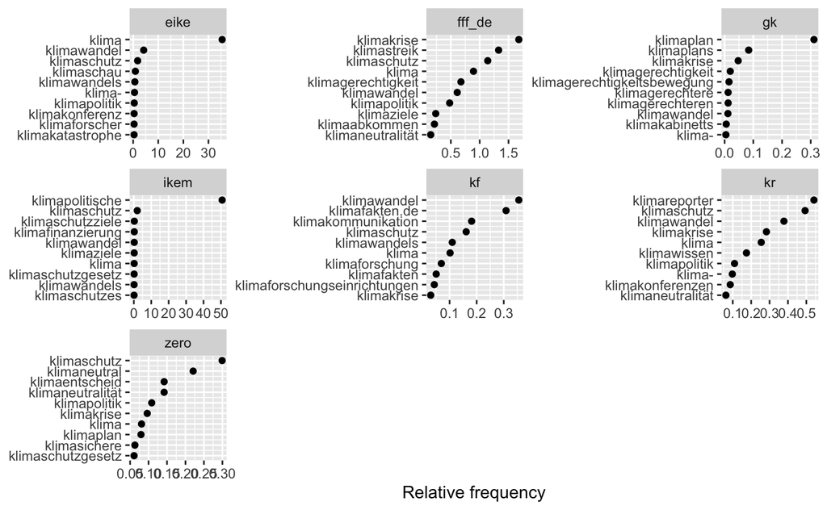

```r
# create a weighted dfm for the full corpus to get data for each website
dfm_weight_origin <- full_corpus %>%
  tokens(remove_punct = TRUE) %>%
  tokens_remove(full_stopwords) %>%
  dfm() %>%
  dfm_weight(scheme = "prop")

# retrieve all words starting with "klima..."
dfm_klima <- dfm_select(dfm_weight_origin, pattern ="klima*")

# retrieve frequencies
freq_weight <- textstat_frequency(dfm_klima, n=10, groups=dfm_weight_origin$origin)

# plot relative frequencies of all websites
plot7 <- ggplot(data = freq_weight, aes(x = nrow(freq_weight):1, y = frequency)) +
     geom_point() +
     facet_wrap(~ group, scales = "free") +
     coord_flip() +
     scale_x_continuous(breaks = nrow(freq_weight):1,
                        labels = freq_weight$feature) +
     labs(x = NULL, y = "Relative frequency")
plot7
```

The following plot provides a lot of information about the usage of terms between both groups - activists and sceptics.

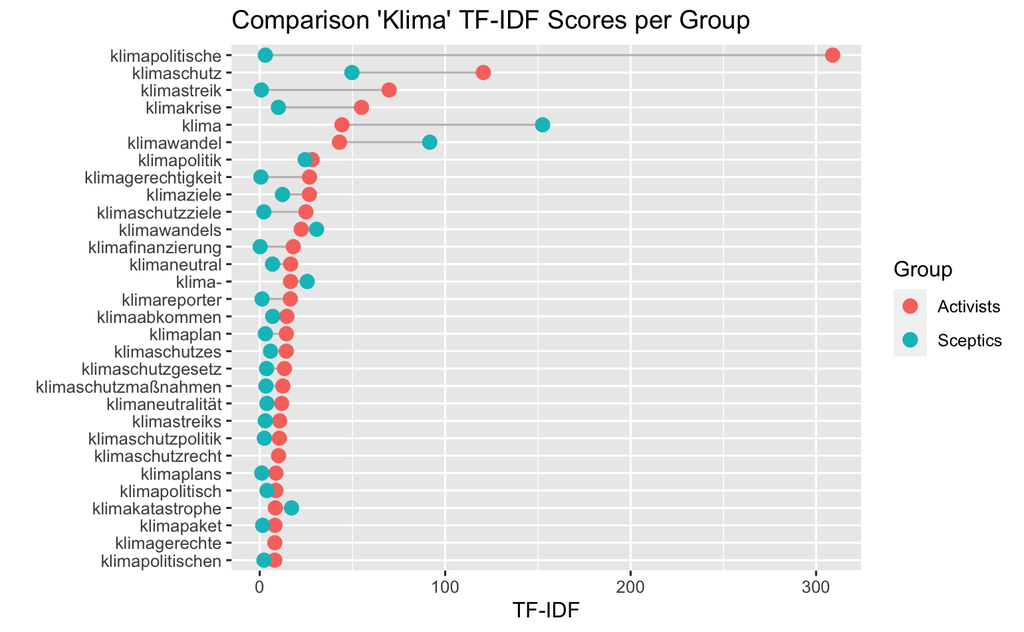

```r
# retrieve frequencies for "klima" words
freqs_pro <- textstat_frequency(p2000_tfidf, force=TRUE)
freqs_con <- textstat_frequency(c2000_tfidf, force=TRUE)

#plot comparison of both groups
freqs.act <- filter(freqs_pro) %>% as.data.frame() %>% select(feature, frequency)
freqs.scept <- filter(freqs_con) %>% as.data.frame() %>% select(feature, frequency)
freqs <- left_join(freqs.act, freqs.scept, by = "feature") %>% head(30) %>% arrange(frequency.x) %>% mutate(feature = factor(feature, feature))
plot8 <- ggplot(freqs) +
    geom_segment(aes(x=feature, xend=feature, y=frequency.x, yend=frequency.y), color="grey") +
    geom_point(aes(x=feature, y=frequency.x, colour="Activists"), size = 3) +
    geom_point(aes(x=feature, y=frequency.y, colour="Sceptics"), size = 3) +
    ggtitle("Comparison 'Klima' TF-IDF Scores per Group") +
    xlab("") + ylab("TF-IDF") +
    coord_flip()

plot8+labs(colour="Group")
```

```r
#ggsave("comparison_klima_freqs.png", dpi=300, dev='png', height=6, width=12, units="in")
```

#### Keyness

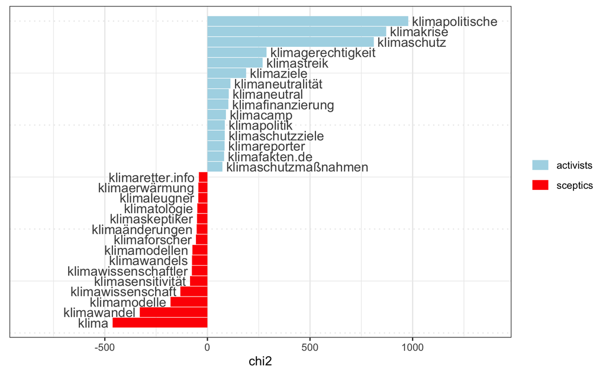

```r
# Create a dfm grouped by community
group_dfm <- tokens(full_corpus, remove_punct = TRUE) %>%
  tokens_remove(full_stopwords) %>%
  tokens_group(groups = group) %>%
  dfm()

# retrieve "klima" words for grouped dfm
group_dfm_klima <- dfm_select(group_dfm, pattern ="klima*")

# Calculate keyness and determine activists as target group
result_keyness <- textstat_keyness(corp_dfm_klima, target = "activists")

# Plot estimated word keyness
textplot_keyness(result_keyness, margin=0.2, n=15, color=c("lightblue", "red"), show_legend=TRUE)
```

### 4.3 Context Analysis

#### Collocations

```r
# Preprocessing of the corpora to remove stopwords and special characters, etc.
pro2000_tokens <- pro2000 %>%
  tokens(remove_punct = TRUE, remove_numbers = TRUE, remove_symbols = TRUE, remove_url = TRUE,
         remove_separators = TRUE) %>%
  tokens_tolower() %>%
  tokens_remove(pattern = full_stopwords, padding = T)

contra2000_tokens <- contra2000 %>%
  tokens(remove_punct = TRUE, remove_numbers = TRUE, remove_symbols = TRUE, remove_url = TRUE,
         remove_separators = TRUE) %>%
  tokens_tolower() %>%
  tokens_remove(pattern = full_stopwords, padding = T)

# calculate collocation via textstat
p_coll <- textstat_collocations(pro2000_tokens, min_count=10)
c_coll <- textstat_collocations(contra2000_tokens, min_count=10)

# get top 50 collocations for activists
p2000_colls <- head(arrange(p_coll, desc(count)), n=50)

# get top50 collocations for sceptics
c2000_colls <- head(arrange(c_coll, desc(count)), n=50)

p2000_colls
```

|  | collocation | count | count_nested | length | lambda | z |
| --- | --- | --- | --- | --- | --- | --- |
| 7 | mehr infos | 752 | 0 | 2 | 7.770344 | 64.860171 |
| 2 | mehr informationen | 727 | 0 | 2 | 6.124807 | 94.305631 |
| 1 | unsere arbeit | 690 | 0 | 2 | 7.702729 | 97.653066 |
| 12 | aktuelle klimapolitische | 679 | 0 | 2 | 11.736602 | 54.692218 |
| 10 | klimapolitische themen | 678 | 0 | 2 | 11.589939 | 55.233972 |
| 3 | arbeit aktuelle | 677 | 0 | 2 | 9.342793 | 91.560982 |
| 150 | year date | 469 | 0 | 2 | 15.388893 | 30.872687 |
| 4 | erneuerbaren energien | 379 | 0 | 2 | 8.280709 | 83.038374 |
| 11 | uhr marktplatz | 304 | 0 | 2 | 6.940821 | 54.836524 |
| 9 | simon schäfer-stradowsky | 299 | 0 | 2 | 11.289034 | 57.618370 |

[output cut: 40 more lines]

```r
c2000_colls
```

|  | collocation | count | count_nested | length | lambda | z |
| --- | --- | --- | --- | --- | --- | --- |
| 22 | chris frey | 502 | 0 | 2 | 13.823905 | 57.19010 |
| 1 | globale erwärmung | 370 | 0 | 2 | 6.971863 | 98.03826 |
| 2 | pro jahr | 360 | 0 | 2 | 6.023702 | 92.00193 |
| 4 | letzten jahre | 325 | 0 | 2 | 5.566067 | 85.15116 |
| 29 | geehrter herr | 321 | 0 | 2 | 9.352467 | 54.33776 |
| 7 | letzten jahren | 310 | 0 | 2 | 5.370873 | 81.31644 |
| 28 | immer mehr | 291 | 0 | 2 | 3.397794 | 54.83418 |
| 6 | frey eike | 279 | 0 | 2 | 7.607852 | 84.01915 |
| 3 | erneuerbaren energien | 259 | 0 | 2 | 8.431458 | 88.32988 |
| 8 | globalen erwärmung | 246 | 0 | 2 | 6.228212 | 80.53599 |

[output cut: 40 more lines]

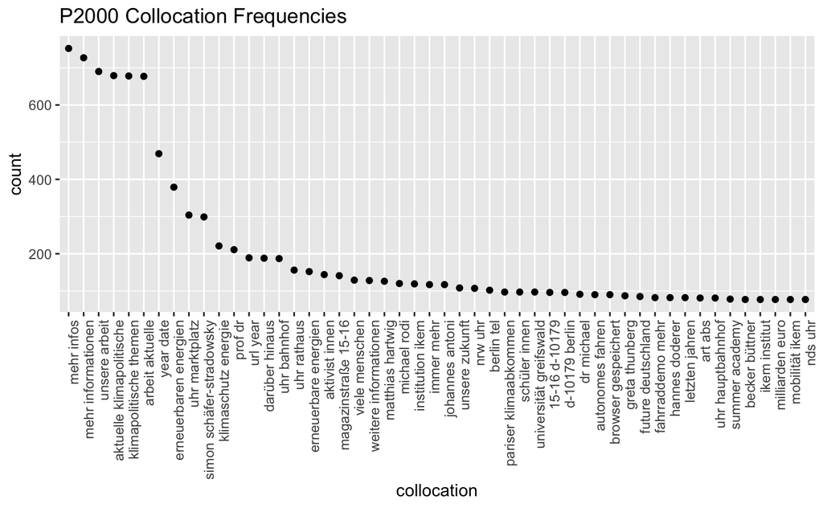

```r
# plot collocations of activists corpus
p2000_colls$collocation <- with(p2000_colls, reorder(collocation, -count))
plot9 <- ggplot(p2000_colls, aes(x=collocation, y=count)) +
  geom_point()+ggtitle("P2000 Collocation Frequencies")+
  theme(axis.text.x = element_text(angle=90,hjust=1))
plot9
```

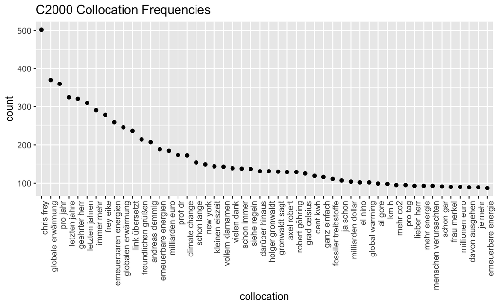

```r
# plot collocations of sceptics corpus
c2000_colls$collocation <- with(c2000_colls, reorder(collocation, -count))
plot10 <- ggplot(c2000_colls, aes(x=collocation, y=count)) +
  geom_point()+ggtitle("C2000 Collocation Frequencies")+
  theme(axis.text.x = element_text(angle=90,hjust=1))
plot10
```

```r
#ggsave(plot=plot9, width = 10, height = 5, dpi=300, filename="p2000_colls.png")
#ggsave(plot=plot10, width = 10, height = 5, dpi=300, filename="c2000_colls.png")
```

#### Keyword in Context

In the following we will output the context of some example words by using the “Keywords-in-Context” (KWIC) feature of Quanteda. #### KWIC: “Klimaschutz” Activists Group

```r
# apply keyword-in-context function for given word
kwic_pro <- kwic(pro2000, pattern="klimaschutz", window=5) %>%
  as_tibble()
# output top20 kwic results
head(kwic_pro, n=20)
```

| docname | from | to | pre | keyword | post | pattern |
| --- | --- | --- | --- | --- | --- | --- |
| fff_de_00311.txt | 982 | 982 | ging es nie nur um | Klimaschutz | und - gerechtigkeit , sondern | klimaschutz |
| ikem_00573.txt | 28 | 28 | Daten durch das Institut für | Klimaschutz | , Energie und Mobilität e.V | klimaschutz |
| ikem_00573.txt | 1651 | 1651 | aktuelle Entwicklungen in den Bereichen | Klimaschutz | und Energie sowie zu Fragen | klimaschutz |
| fff_de_00137.txt | 803 | 803 | nicht nur wichtig für den | Klimaschutz | , sondern machen unsere Städte | klimaschutz |
| fff_de_00313.txt | 2428 | 2428 | könnte zugleich dazu beitragen , | Klimaschutz | sozialgerecht zu gestalten . Industriesektor | klimaschutz |
| kf_00013.txt | 155 | 155 | Deutschland sieht die Notwendigkeit für | Klimaschutz | , empfinden die aktuelle Debatte | klimaschutz |
| kf_00013.txt | 411 | 411 | auch jene zu Klimawandel und | Klimaschutz | . Aber sind die Folgen | klimaschutz |
| kf_00013.txt | 501 | 501 | auch jene zu Klimawandel und | Klimaschutz | . Aber sind die Folgen | klimaschutz |
| kf_00013.txt | 554 | 554 | eine demokratische Klimapolitik mehr 30.03.2021 | Klimaschutz | als Religion zu bezeichnen - | klimaschutz |
| ikem_00403.txt | 195 | 195 | der Gründung des Instituts für | Klimaschutz | , Energie und Mobilität ( | klimaschutz |

[output cut: 10 more lines]

```r
#write.csv(kwic_pro, "kwic_pro_klimaschutz.csv")
```

#### KWIC: “Klimaschutz” Sceptics Group

```r
# apply keyword-in-context function for given word
kwic_con <- kwic(contra2000, pattern="klimaschutz", window=5) %>%
  as_tibble()
# output top20 kwic results
head(kwic_con, n=20)
```

| docname | from | to | pre | keyword | post | pattern |
| --- | --- | --- | --- | --- | --- | --- |
| eike_06606.txt | 466 | 466 | Brandenburg eine „ Verbindung von | Klimaschutz | mit Wertschöpfung , Arbeitsplätze ( | klimaschutz |
| eike_02519.txt | 120 | 120 | enthält den Beitrag „ Erfolgreicher | Klimaschutz | durch zügigen Kohleausstieg in Deutschland | klimaschutz |
| eike_10657.txt | 3381 | 3381 | von Umwelt- und Klimapolitik . | Klimaschutz | braucht die Menschheit nicht im | klimaschutz |
| eike_05933.txt | 2478 | 2478 | mitgetragen , ebenso der „ | Klimaschutz | " . Ob jemand CDU | klimaschutz |
| eike_09268.txt | 72 | 72 | Kolumne für höhere Spritpreise zum | Klimaschutz | : „ … aber da | klimaschutz |
| eike_09268.txt | 100 | 100 | es ernst meint mit dem | Klimaschutz | , der muss fossile Brennstoffe | klimaschutz |
| eike_12176.txt | 106 | 106 | „ Rechtspopulisten " und „ | Klimaschutz | " in Europa auch etwas | klimaschutz |
| eike_09456.txt | 1141 | 1141 | Beitrag „ Neun Fragen zum | Klimaschutz | " zitierte Herr Prof.Lüdecke die | klimaschutz |
| eike_11176.txt | 6167 | 6167 | , also ohne wesentliche „ | Klimaschutz | " -Maßnahmen . Diese Abbildung | klimaschutz |
| eike_08661.txt | 8 | 8 | Aurel erst kürzlich in „ | Klimaschutz | in Absurdistan , EIKE , | klimaschutz |

[output cut: 10 more lines]

#### KWIC: “Klimakrise” Activists Group

```r
# apply keyword-in-context function for given word
kwic_pro <- kwic(pro2000, pattern="klimakrise", window=5) %>%
  as_tibble()
# output top20 kwic results
head(kwic_pro, n=20)
```

| docname | from | to | pre | keyword | post | pattern |
| --- | --- | --- | --- | --- | --- | --- |
| fff_de_00139.txt | 40 | 40 | macht gerade eindrücklicher auf die | Klimakrise | aufmerksam als der Planet selbst | klimakrise |
| fff_de_00139.txt | 644 | 644 | die gesellschaftliche Debatte über die | Klimakrise | dürfen nicht davon abhängen , | klimakrise |
| fff_de_00139.txt | 752 | 752 | Zeichen dafür , dass die | Klimakrise | in der Mitte der Gesellschaft | klimakrise |
| fff_de_00139.txt | 801 | 801 | sich ganz zentral um die | Klimakrise | drehen wird - eine Tatsache | klimakrise |
| fff_de_00139.txt | 984 | 984 | diejenigen über den Ausgang der | Klimakrise | entscheiden , die ein politisches | klimakrise |
| fff_de_00139.txt | 1035 | 1035 | Ein Kommentar zu „ Die | Klimakrise | wartet nicht auf einen Impfstoff | klimakrise |
| fff_de_00311.txt | 227 | 227 | dass niemand mehr an der | Klimakrise | vorbeikommen wird . Ob jung | klimakrise |
| fff_de_00052.txt | 118 | 118 | in der Coronakrise eskaliert die | Klimakrise | bisher ungebremst . Wir können | klimakrise |
| fff_de_00226.txt | 225 | 225 | allerdings ausreicht , um die | Klimakrise | abzuhalten , ist dann doch | klimakrise |
| fff_de_00137.txt | 17 | 17 | für Klimagerechtigkeit - denn die | Klimakrise | wird im Moment auf dem | klimakrise |

[output cut: 10 more lines]

```r
# write.csv(head(kwic_pro, n=20), "kwic_pro_klimakrise.csv")
```

#### KWIC: “Klimakrise” Sceptics Group

```r
# apply keyword-in-context function for given word
kwic_con <- kwic(contra2000, pattern="klimakrise", window=5) %>%
  as_tibble()
# output top20 kwic results
head(kwic_con, n=20)
```

| docname | from | to | pre | keyword | post | pattern |
| --- | --- | --- | --- | --- | --- | --- |
| eike_01807.txt | 112 | 112 | anerkannter Klimaforscher ? - „ | Klimakrise | " fehl am Platz Das | klimakrise |
| eike_01807.txt | 1186 | 1186 | zur Abwendung einer dramatischen „ | Klimakrise | " unbedingt das im Pariser | klimakrise |
| eike_10128.txt | 7 | 7 | Öllerer Wer von einer heutigen | Klimakrise | redet , der sollte sich | klimakrise |
| eike_10128.txt | 100 | 100 | , dass wir in einer | Klimakrise | stecken , weil es seit | klimakrise |
| eike_13214.txt | 2429 | 2429 | der Globale Norden erst die | Klimakrise | auslöst und dann sagt , | klimakrise |
| eike_13535.txt | 95 | 95 | Übergang nennen würde : Die | Klimakrise | hingegen schieben viele weg , | klimakrise |
| eike_13535.txt | 115 | 115 | , zumal es gegen die | Klimakrise | nie einen Impfstoff geben wird | klimakrise |
| eike_13535.txt | 831 | 831 | Corona haben wir gegen die | Klimakrise | schon einen Impfstoff . " | klimakrise |
| eike_10603.txt | 1693 | 1693 | Energiewende " und der „ | Klimakrise | " wird auf dieser Seite | klimakrise |
| eike_02933.txt | 6 | 6 | Neues aus der Anstalt - | Klimakrise | ist jetzt „ Wass . | klimakrise |

[output cut: 10 more lines]

#### KWIC: “Klimahysterie” Scpetics Group

```r
# apply keyword-in-context function for given word
kwic_con <- kwic(contra2000, pattern="klimahysterie", window=5) %>%
  as_tibble()
# output top20 kwic results
head(kwic_con, n=20)
```

| docname | from | to | pre | keyword | post | pattern |
| --- | --- | --- | --- | --- | --- | --- |
| eike_09675.txt | 1488 | 1488 | wie auch die ganze „ | Klimahysterie | " . Es gibt keinen | klimahysterie |
| eike_10545.txt | 1604 | 1604 | mir nach diversen Virushysterien die | Klimahysterie | gerade rechtzeitig . So habe | klimahysterie |
| eike_09718.txt | 417 | 417 | es den führenden Protagonisten der | Klimahysterie | keineswegs um das Klima geht | klimahysterie |
| eike_09718.txt | 436 | 436 | zu nehmen . Die geschürte | Klimahysterie | mit ihrer metastatischen Durchdringung inzwischen | klimahysterie |
| eike_13062.txt | 56 | 56 | . Mit dem Siegeszug der | Klimahysterie | in den Regierungen , der | klimahysterie |
| eike_09342.txt | 12 | 12 | die Massenmedien , daß „ | Klimahysterie | " das Unwort des Jahres | klimahysterie |
| eike_09342.txt | 26 | 26 | dazu verbreiteten die Medien ordentlich | Klimahysterie | , indem sie von kochenden | klimahysterie |
| eike_06489.txt | 1513 | 1513 | ist . Es hat eine | Klimahysterie | mit religiösen Untertönen geschaffen . | klimahysterie |
| eike_06788.txt | 2487 | 2487 | der Erderwärmung zu ängstigen . | Klimahysterie | herrscht in China weder in | klimahysterie |
| eike_00728.txt | 107 | 107 | gerade derjenigen , welche der | Klimahysterie | und der desaströsen Energiewende das | klimahysterie |

[output cut: 10 more lines]

```r
# write.csv(head(kwic_con, n=20), "kwic_con_klimahysterie.csv")
```

### Glossary Enrichment

Export lists of “Klima” words from both groups for later use in glossary and glossary enrichment.

```r
# set max print option to make sure all results are saved to final list
options(max.print=10000)

# retrieve all "Klima" words from both corpora
pro_klima_list <- list(textstat_frequency(dfm_select(sp_pro2000_dfm, pattern = "klima*"))$feature)
con_klima_list <- list(textstat_frequency(dfm_select(sp_con2000_dfm, pattern = "klima*"))$feature)

# create combined list
shared <- Map(c, pro_klima_list, con_klima_list)

# to save lists of "Klima" words
# w/o "$feature" it saves the whole table as text file (with frequency info etc.)
capture.output(pro_klima_list, file = "terms_pro.txt")
capture.output(con_klima_list, file = "terms_contra.txt")
capture.output(shared, file = "terms_shared.txt")
```

The activists list contains 826 terms.

```r
lengths(pro_klima_list)
```

```
[1] 826
```

The sceptics list contains 2141 terms.

```r
lengths(con_klima_list)
```

```
[1] 2141
```

The combined list contains 2967 terms.

```r
lengths(shared)
```

```
[1] 2967
```